# Calculated Features to Capture Customer Order Behaviour in Time

Joseph Bolton

```r
library(tidyverse)
library(lubridate)
library(patchwork)
library(broom)
```

```r
gen_random_timeofday <- function(){
  hour <- sample( 8:16, size=1 ) %>% as.character()
  minute <- sample( 0:59, size=1 ) %>% as.character()
  hour <- str_pad( string=hour, width=2, side="left", pad="0")
  minute <- str_pad( string=minute, width=2, side="left", pad="0")
  return( paste0(hour, ":", minute) )
}

gen_random_timeofday()
```

```
## [1] "09:20"
```

```r
gen_random_timeofday()
```

```
## [1] "12:19"
```

```r
gen_random_timeofday()
```

```
## [1] "11:39"
```

```r
# gen_customer_order_viz <- function( order_date_vec,
#                                     xlim = c( lubridate::date("2018-01-01"),
#                                               lubridate::date("2019-12-31")
#                                             ),
#                                     cluster_proximity = 7   # all orders within this distance of one another
#                                                             # will be treated as 1 order
#                                   ){
#
#     order_date_vec <- lubridate::date( order_date_vec )
#     start_date <- xlim[1]
#     end_date <- xlim[2]
#
#     plot_data <- tibble( date = order_date_vec,
#                            y = 0,
#                          grp = "customer"    # add this because geom_line compains otherwise
#                        ) %>%
#             mutate( gaplength = date - lag(date) )
#
#     #
#
#     sd_gaplength <- sd(plot_data$gaplength, na.rm=TRUE)
#
#     return(
#             ggplot( data = plot_data,
#                     aes(     x = date,
#                              y = y,
#                          group = grp
#                         )
#                   ) +
#             geom_point(colour="red", size=3) +
#             geom_line() +
#             geom_vline( aes(xintercept = date), colour = "red" ) +
#             geom_text( aes(label=week_number), hjust=2, angle=90 ) +
#             labs( subtitle = paste0( "SD_gaplength: ", round(sd_gaplength),
#                                      "\n",
#                                      "n_orders_past_7days: ", plot_data %>% filter( date >= (end_date-7) ) %>% nrow(),
#                                      "\n",
#                                      "n_orders_past_14days: ", plot_data %>% filter( date >= (end_date-14) ) %>% nrow(),
#                                      "\n",
#                                      "n_orders_past_30days: ", plot_data %>% filter( date >= (end_date-30) ) %>% nrow()
#                                     )
#                 ) +
#             xlim( xlim )
#
#     )
#
#
# }
#
# gen_customer_order_viz( order_date_vec = c("2018-01-01", "2018-01-05", "2018-01-31", "2018-03-01") )
```

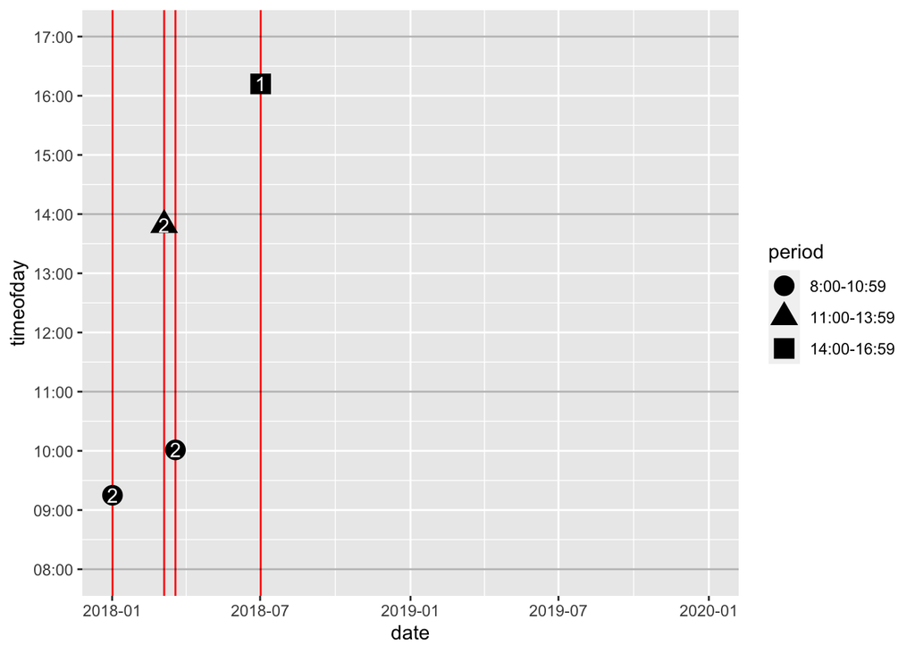

```r
gen_customer_order_viz2 <- function( order_datetime_vec,
                                     xlim = c( lubridate::as_datetime("2018-01-01 00:00:00"),
                                               lubridate::as_datetime("2019-12-31 23:59:59")
                                             ),
                                     ylim = as.POSIXct( strptime(c("08:00",
                                                                   "17:00"), format = "%H:%M")
                                                      )
                                   ){

    order_datetime_vec <- lubridate::as_datetime( order_datetime_vec )
    start_date_time <- xlim[1]
    end_date_time <- xlim[2]

    plot_data <- tibble(      date = order_datetime_vec,
                         timeofday = as.POSIXct(
                                          strftime(order_datetime_vec, format="%H:%M"),
                                          format = "%H:%M"
                                          ) - 2*60*60,
                               grp = "customer"    # add this because geom_line compains otherwise
                        ) %>%
             mutate( gaplength = difftime( date,lag(date), unit="days" ) ) %>%
             mutate( dayofweek = lubridate::wday(date) ) %>%
             mutate( period = case_when( lubridate::hour(date) < 11 ~ "8:00-10:59",
                                         lubridate::hour(date) %in% c(11,12,13) ~ "11:00-13:59",
                                         lubridate::hour(date) > 13 ~ "14:00-16:59",
                                       )
                   ) %>%
             mutate( period = factor(period, levels=c("8:00-10:59", "11:00-13:59", "14:00-16:59") ))


    return(
             ggplot( data = plot_data,
                     aes(     x = date,
                              y = timeofday,
                          group = grp,
                          label = dayofweek,
                          shape = period
                        )
                   ) +
             geom_vline( aes(xintercept = date), colour = "red" ) +
             geom_hline( yintercept = c(as.POSIXct( strptime(c("08:00",
                                                                 "11:00",
                                                                 "14:00",
                                                                 "17:00"), format = "%H:%M")
                                                      )),
                         alpha = 0.3
                        ) +
             geom_point( colour="black", size=5) +
             geom_text( colour = "white" ) +
             xlim( xlim ) +
             scale_y_datetime( limits = ylim,
                               breaks = c(as.POSIXct( strptime(c("08:00",
                                                                 "09:00",
                                                                 "10:00",
                                                                 "11:00",
                                                                 "12:00",
                                                                 "13:00",
                                                                 "14:00",
                                                                 "15:00",
                                                                 "16:00",
                                                                 "17:00"), format = "%H:%M")
                                                      )),
                               labels = c("08:00",
                                                                 "09:00",
                                                                 "10:00",
                                                                 "11:00",
                                                                 "12:00",
                                                                 "13:00",
                                                                 "14:00",
                                                                 "15:00",
                                                                 "16:00",
                                                                 "17:00")
                             )
     )


}

gen_customer_order_viz2( order_datetime_vec = c("2018-01-01 09:15:36", "2018-03-05 13:49:02", "2018-03-19 10:01:02", "2018-07-01 16:12:58") )
```

# Recency

When was the last time that the customer was active?

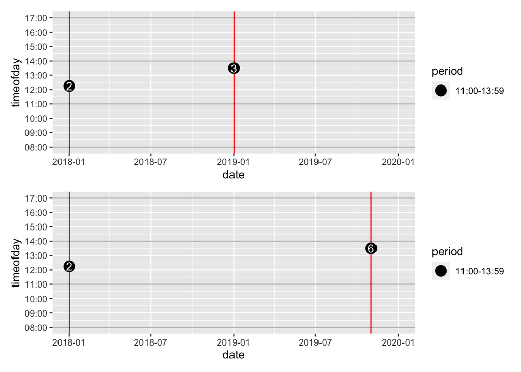

Features describing *recency*:

1. Number of days since last transaction
2. Number of days since customer had $x$ close transactions (e.g. how many days ago did customer have 3 transactions, where those transactions were a maximum of 1 month apart). This is a stricter definition of an *active* customer, requiring a number of transactions in close proximity in time.

# Consistency

How consistent is a customer in their transactions, in terms of amount of time between each transaction?

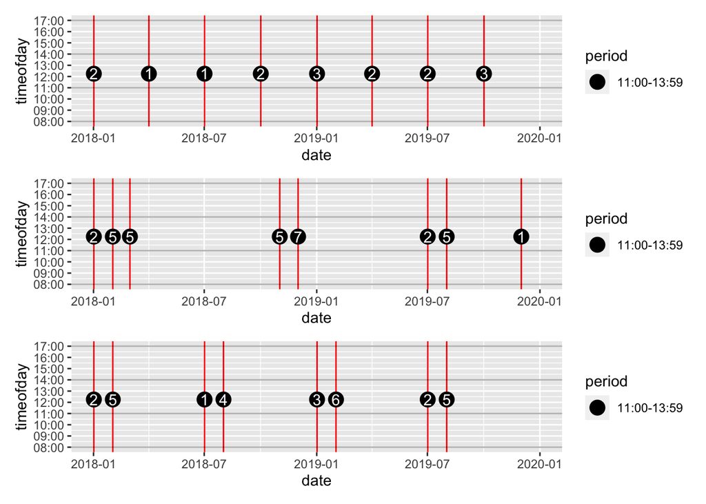

Meausures of consistency:

1. Standard Deviation of Gap Length (gap length=number of days between 2 transactions).
2. Standard Deviation of gap length, where data is first binned into active weeks (week containing at least one transaction) and inactive weeks (week containing no transactions). *Gap length* is then defined as number of inactive weeks between any 2 given active weeks.
3. Standard Deviation of gap length, where data is first binned into active months (month containing at least one transaction) and inactive months (month containing no transactions). *Gap length* is then defined as number of inactive months between any 2 given active months.
4. $\text{max}(gapsize) - \text{min}(gapsize)$.

# Trajectory

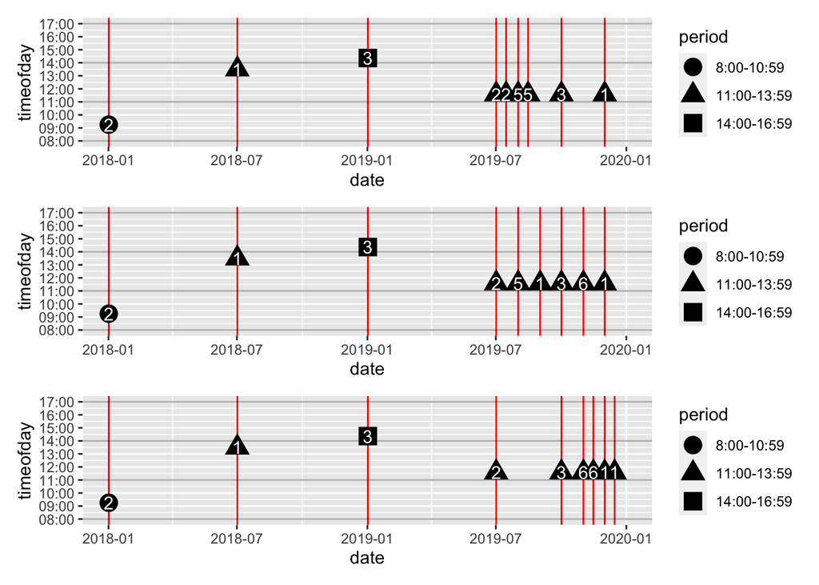

Measures of trajectory:

1. *Trajectory in last $x$ weeks*: Count number of transactions per week in the last $x$ months. Fit an OLS line to the relationship **n_transactions ~ time**. The slope of this line is a measure of the trajectory of the last $x$ months.
2. *Trajectory in last $x$ weeks*: Count number of transactions per week in the last $x$ months. For each week, calculate the change in number of transactions (absolute or %) for this week compared to every subsequent week. Define the trajectory as the average of these changes.

# Frequency

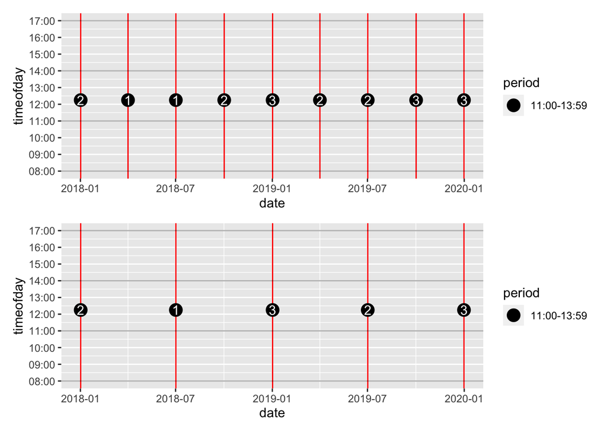

Measures of frequency:

1. Number of transactions in last $x$ weeks.

# Day-of-Week Preference

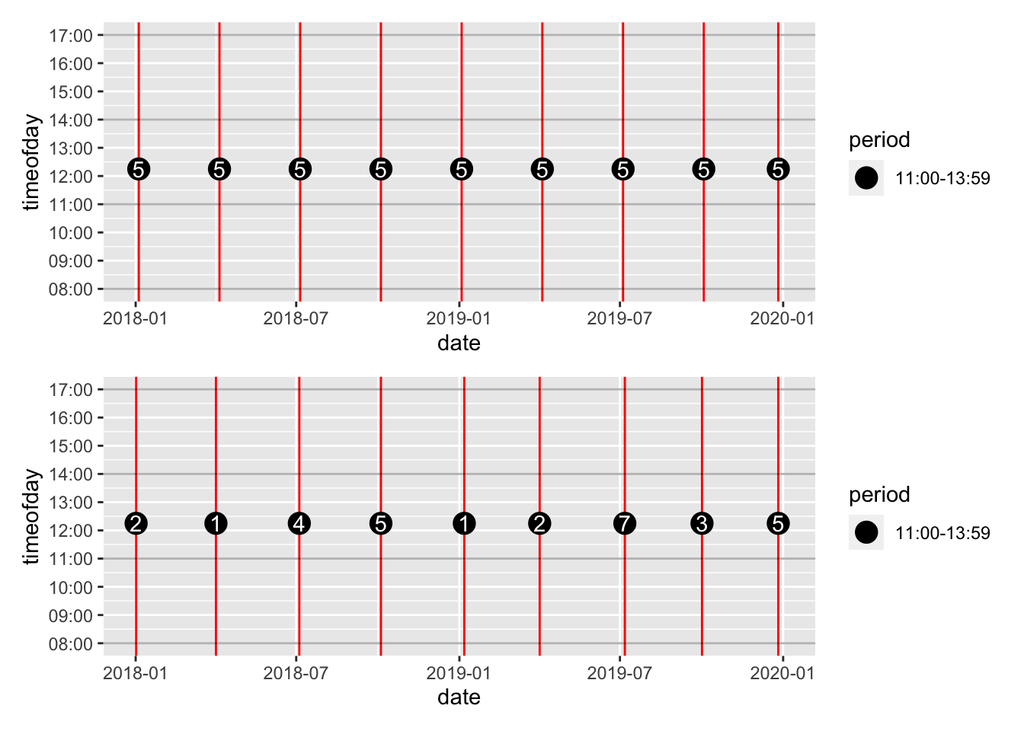

# Time-of-Day Preference

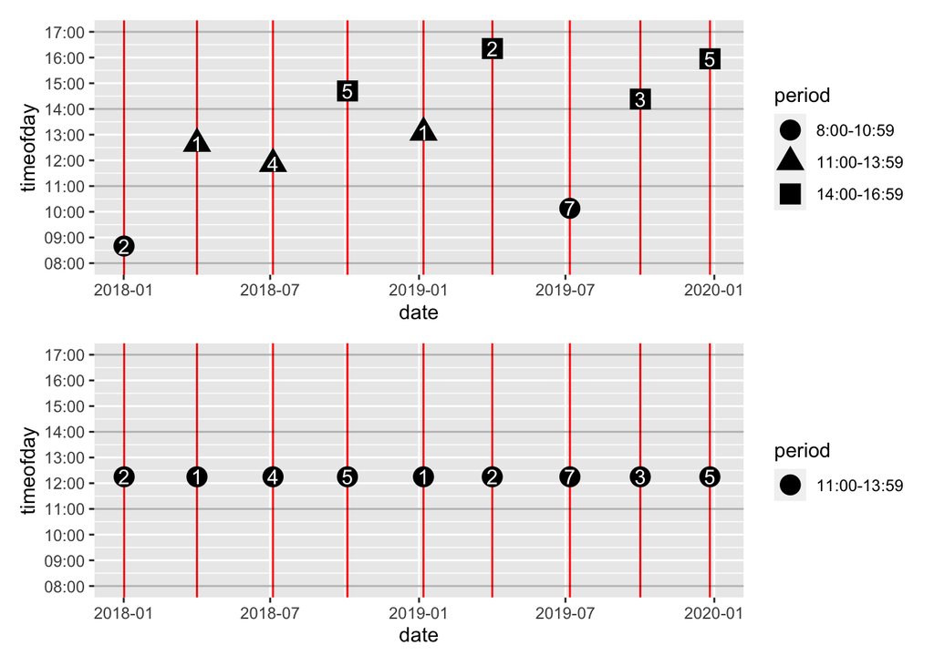

# Change in behaviour regime

Compare change in various metrics over 2 consecutive periods.